# HW8

## Part 3- ParFlow Model Simulation

Simulate the system with ParFlow using the notebook included running on Adroit (runoff-generation.ipynb and domain.pfsol). First run the base case for Hortonian flow (i.e. just run the notebook) and quantitatively compare output to Parts 1 and 2 above. Then, increase the hydraulic conductivity (as indicated in the notebook) so that a change in runoff production occurs. What value is needed to accomplish this and why? Is there flow at the outlet and why? Next, adjust the water table depth as shown in the notebook. What does this do to the production of runoff for the system?

Below I run the ParFlow model simulation as it is written.

```python
import parflow as pf

from glob import glob
import matplotlib.pyplot as plt
import numpy as np
from parflow.tools.fs import get_absolute_path, cp, rm, mkdir, exists


N=100
time    = np.arange(N)    # time array, we will probably want to swap with a date (not applicaple to JMH)
base_dir = get_absolute_path(".")

files = glob(base_dir+"/dunne_over/Dunne.out.satur.*.pfb")
sat = pf.read_pfb_sequence(files)
files = glob(base_dir+"/dunne_over/Dunne.out.press.*.pfb")
press = pf.read_pfb_sequence(files)
files = glob(base_dir+"/dunne_over/Dunne.out.overlandsum.*.pfb")
overland_sum = pf.read_pfb_sequence(files)
```

### Calculate total flow from the domain

to get total flow we use Manning's equation times the height of water $h$ times the width of the outlet, times the timestep

$q [m^3] = \dfrac{\sqrt{S_0}}{n}\times h^{2/3} \times h \times \Delta t \times \Delta y$

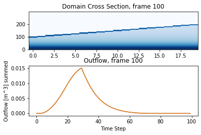

```python
# slope and Manning's n
mannings = 1e-5
slope = 0.05

# calculate outflow first by reading from ParFlow
outflow = overland_sum[:,0,0,0]
##  next using manning's eq
## total flow out of the domain is

outflow_m= (np.sqrt(slope)/mannings) * np.maximum(press[:,102,0,0],0.0)**(5.0/3.0)*0.01*1.0

# set a variable for the timestep plotted in saturation cross section
icount = 100

## Plot results
## three subplots
fig, ax = plt.subplots(2)

ax[0].cla()
ax[0].imshow(sat[icount,:,0,:],vmin=0.1, vmax=1.0,origin='lower',aspect=0.015,cmap='Blues',interpolation='none')  #,extent=[0,100,0,1])
ax[0].set_title("Domain Cross Section, frame {}".format(icount))

ax[1].cla()
ax[1].plot(time,outflow)
ax[1].plot(time,outflow_m[1:102])
ax[1].set_title("Outflow, frame {}".format(icount))
ax[1].set_xlabel("Time Step")
ax[1].set_ylabel("Outflow [m^3] summed")


plt.show()
```

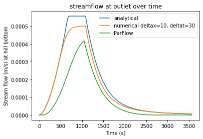

```python
time1 = np.arange(0,t_total,30)

# plot the numerical, analytical, and ParFlow solutions (with a unit conversion for ParFlow)
# and a temporal scaling (ParFlow is only run for 100 time steps)
plt.plot(time1,v_array, label='analytical')
plt.plot(time1,v_finite_difference, label='numerical deltax=10, deltat=30')
plt.plot(time*36,outflow_m[1:102]/(36), label='ParFlow')
plt.xlabel("Time (s)")
plt.ylabel("Stream flow (m/s) at hill bottom")
plt.title("streamflow at outlet over time")
plt.legend()
plt.show()
```

I see that the ParFlow model greatly underestimates flow at the bottom of the hill. The model might might take into account higher evaporation, greater soil moisture content, or other factors concerning groundwater. Next, I rerun the ParFlow model testing different values of hydraulic conductivity. As expected, given a rainfall rate of 0.02 m/h, we will observe no overland flow if K = 0.02. This is the point at which precipitation = infiltration.

[figure not shown]

```python
time1 = np.arange(0,t_total,30)

# plot the numerical, analytical, and ParFlow solutions (with a unit conversion for ParFlow)
# and a temporal scaling (ParFlow is only run for 100 time steps)
plt.plot(time1,v_array, label='analytical')
plt.plot(time1,v_finite_difference, label='numerical deltax=10, deltat=30')
plt.plot(time*36,outflow_m[1:102]/(36), label='ParFlow, K=0.02')
plt.xlabel("Time (s)")
plt.ylabel("Stream flow (m/s) at hill bottom")
plt.title("streamflow at outlet over time")
plt.legend()
plt.show()
```

Next, I will increase the water table depth, assuming 0 hydraulic conductivity. I find that as I increase the water table depth to 5m, the overland flow increases. This makes sense, as a higher water table could contribute more water to the runoff at the surface of the hill.

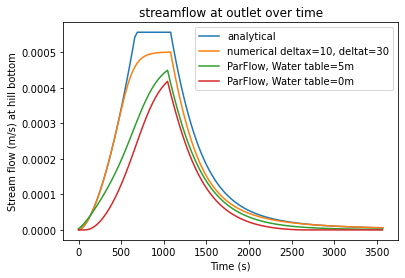

```python
time1 = np.arange(0,t_total,30)

# plot the numerical, analytical, and ParFlow solutions (with a unit conversion for ParFlow)
# and a temporal scaling (ParFlow is only run for 100 time steps)
plt.plot(time1,v_array, label='analytical')
plt.plot(time1,v_finite_difference, label='numerical deltax=10, deltat=30')
plt.plot(time*36,outflow_m1[1:102]/(36), label='ParFlow, Water table=5m')
plt.plot(time*36,outflow_m[1:102]/(36), label='ParFlow, Water table=0m')
plt.xlabel("Time (s)")
plt.ylabel("Stream flow (m/s) at hill bottom")
plt.title("streamflow at outlet over time")
plt.legend()
plt.show()
```

[output not shown]

## Part 4 Analysis

Compare, contrast and discuss the approaches used to calculate overland flow in this assignment. What are the advantages and disadvantages of each?

The finite difference method, analytical solution, and ParFlow model all have advantages and disadvantages. First, the ParFlow model allows the user to experiment with the environment of the overland flow scenario. For instance, in this assignment we were able to tinker with the water table depth and hydraulic conductivity. Doing so enables us to draw relationships between the parameters of the environment and overland flow, so we can better understand the system. However, running the ParFlow model is complex and requires us to know very specific details about our system (as you can see above, it differs greatly from the analytical and numerical solutions). The analytical and numerical solutions are simpler to compute and require fewer input parameters than the ParFlow model. However, they do not fully encapsulate all the complexities of the hillslope like the ParFlow model. The analytical solution and numerical solution provide a good baseline for a simple calculation of overland flow, however they are highly dependent on using stable conditions for deltax and deltat. Also, the numerical solution can greatly vary depending on your chosen step sizes.